# Projections using Generalized Richards Model

## Load the necessary libaries

```r
library(tidyr)
library(dplyr)
```

```r
library(ggplot2)
library(lubridate)
library(reshape2)
library(gridExtra)
library(deSolve)
library(minpack.lm)
library(incidence)
```

## Load the data

Will be using data made available by Johns Hopkins Center for Systems Science and Engineering (CSSE) https://github.com/CSSEGISandData/COVID-19.git

**Confirmed cases**

```r
cases <- read.delim('data/covid-19/csse_covid_19_data/csse_covid_19_time_series/time_series_covid19_confirmed_global.csv',
                           sep = ',', header = TRUE, stringsAsFactors = FALSE) %>%
  rename(country = Country.Region, province = Province.State, lat = Lat, lon = Long)
cases <- reshape2::melt(cases, id.vars = c('country', 'province', 'lat', 'lon'),
                             variable.name = 'date', value.name = 'cum_cases') %>%
  mutate(date = as.Date(date, "X%m.%d.%y")) %>%
  group_by(country, province) %>%
  mutate(cases = c(cum_cases[1], diff(cum_cases))) %>%
  filter(cases >= 0)
cases$country[cases$country == "Taiwan*"] <- "Taiwan"
cases
```

```
## # A tibble: 21,374 x 7
## # Groups:   country, province [264]
##    country         province                lat    lon date       cum_cases cases
##    <chr>           <chr>                 <dbl>  <dbl> <date>         <int> <int>
##  1 Afghanistan     ""                     33    65    2020-01-22         0     0
##  2 Albania         ""                     41.2  20.2  2020-01-22         0     0
##  3 Algeria         ""                     28.0   1.66 2020-01-22         0     0
##  4 Andorra         ""                     42.5   1.52 2020-01-22         0     0
##  5 Angola          ""                    -11.2  17.9  2020-01-22         0     0
##  6 Antigua and Ba~ ""                     17.1 -61.8  2020-01-22         0     0
##  7 Argentina       ""                    -38.4 -63.6  2020-01-22         0     0
##  8 Armenia         ""                     40.1  45.0  2020-01-22         0     0
##  9 Australia       "Australian Capital ~ -35.5 149.   2020-01-22         0     0
## 10 Australia       "New South Wales"     -33.9 151.   2020-01-22         0     0
## # ... with 21,364 more rows
```

```r
# Confirmed deaths in the world
deaths <- read.delim('data/covid-19/csse_covid_19_data/csse_covid_19_time_series/time_series_covid19_deaths_global.csv',
                           sep = ',', header = TRUE, stringsAsFactors = FALSE) %>%
  rename(country = Country.Region, province = Province.State, lat = Lat, lon = Long)
deaths <- reshape2::melt(deaths, id.vars = c('country', 'province', 'lat', 'lon'),
                             variable.name = 'date', value.name = 'cum_deaths') %>%
  mutate(date = as.Date(date, "X%m.%d.%y")) %>%
  group_by(country, province) %>%
  mutate(deaths = c(cum_deaths[1], diff(cum_deaths))) %>%
  filter(deaths >= 0)
deaths$country[deaths$country == "Taiwan*"] <- "Taiwan"
deaths
```

```
## # A tibble: 21,371 x 7
## # Groups:   country, province [264]
##    country        province               lat    lon date       cum_deaths deaths
##    <chr>          <chr>                <dbl>  <dbl> <date>          <int>  <int>
##  1 Afghanistan    ""                    33    65    2020-01-22          0      0
##  2 Albania        ""                    41.2  20.2  2020-01-22          0      0
##  3 Algeria        ""                    28.0   1.66 2020-01-22          0      0
##  4 Andorra        ""                    42.5   1.52 2020-01-22          0      0
##  5 Angola         ""                   -11.2  17.9  2020-01-22          0      0
##  6 Antigua and B~ ""                    17.1 -61.8  2020-01-22          0      0
##  7 Argentina      ""                   -38.4 -63.6  2020-01-22          0      0
##  8 Armenia        ""                    40.1  45.0  2020-01-22          0      0
##  9 Australia      "Australian Capital~ -35.5 149.   2020-01-22          0      0
## 10 Australia      "New South Wales"    -33.9 151.   2020-01-22          0      0
## # ... with 21,361 more rows
```

## China

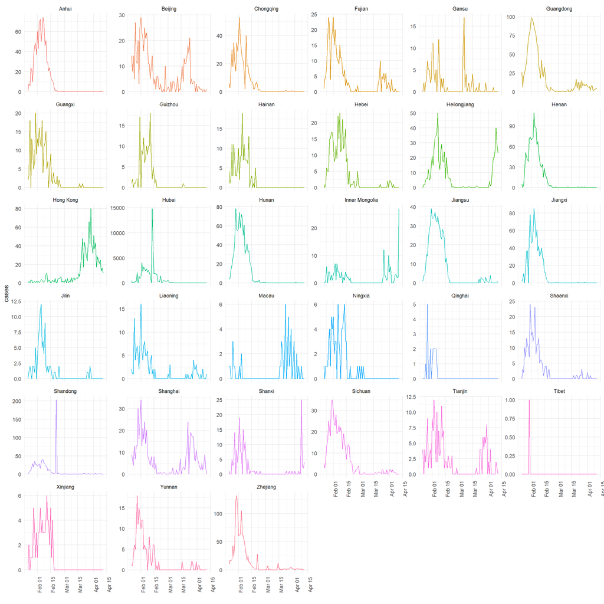

```r
cases %>% filter(country == "China") %>%
  ggplot(., aes(x = date, y = cases, color = province)) +
  geom_line() +
  facet_wrap(~ province, scales = "free_y") +
  labs(x = "") +
  theme_minimal() +
  theme(legend.position = 'none',
        axis.text.x = element_text(angle = 90))
```

**Function to fit a Generalized Richards Model to cumulative incidence data**

Define the GRM differential equation given by:
$$dC/dt = r[C(t)]^p(1-C(t)/K)^\alpha$$
, where *C(t)* = cumulative number of cases at time *t* *r* = growth rate at the early stage *p* $\epsilon$ [0, 1] = parameter that allows the model to capture different growth profiles including the constant incidence ( *p* = 0), sub-exponential-growth (0 < *p* < 1) and exponential growth ( *p* = 1) $\alpha$ = measures the deviation from the symmetric s-shapes dynamics of the simple logistic curve

The model recovers the original Richards model for *p* = 1 and reduces to teh generalized logistic model for $\alpha$ = and *p* = 1

Source: [Wu et al. (2020)](https://arxiv.org/ftp/arxiv/papers/2003/2003.05681.pdf)

```r
# Generalized Richards model (GRM)
GRM <- function(time, state, parameters) {
  par <- as.list(c(state, parameters))
  with(par, {
    dC <- r * (C^p) * (1 - (C/K)^a)
    return(list(c(dC)))
  })
}
```

We need a solver to solve the ordinary differential equation and an optimizer for the parameters *K, r, p, $\alpha$*. We’ll use the function `ode` from the `deSolve` package and the base function `optim` to achieve this.

```r
optimizer <- function(cum_cases, K_start = 10000, r_start = 1, p_start = 0.5, a_start = 1.5) {
  # Solver for the GRM

  RSS <- function(parameters) {
    names(parameters) <- c('K', 'r', 'p', 'a')
    times <- 1:length(cum_cases)
    out <- ode(y = init, times = times, func = GRM, parms = parameters)
    fit <- out[, 2]
    sum((cum_cases - fit)^2)
  }

  # Initialize the parameters
  init <- c(C = 1)
  # K_start <- if (is.null(K_start)) median(cum_cases)
  pars <- c(K = K_start, r = r_start, p = p_start, a = a_start)


  # Optimizer of the parameters using RSS
  Opt <- optim(pars, RSS, method = "L-BFGS-B",
               lower = c(0, 0, 0, 0),
               upper = c(10000000, 10, 1, 20))
  return(Opt)
  }
```

Let’s write a function to make predictions based on the fit. As a default, we’ll predict cumulative cases 14 days ahead of the latest date data were collected. We’ll also use those data and uncumulate them to get incidence predictions.

```r
# Prediction function, default is 14 days forward of the last date of observed data
make_preds <- function(df, fit, t_fwd = 14) {
  t <- 1:(as.integer(today() - df$date[1]) + t_fwd)
  # Make predictions based on cumulative incidence
  preds <- data.frame(ode(y = c(C=1), times = t, func = GRM, parms = fit$par))
  preds <- preds %>%
    mutate(date = df$date[1] + days(t-1),
           C = round(C, 0),
           # uncumulate to get incidence
           I = c(C[1], diff(C))) %>%
    left_join(df %>% ungroup() %>% select(date, cum_cases, cases))
  return(preds)
}
```

Lastly, create a plotting fucntion. We’ll plot both the cumulative and incidence fits against the observed data.

```r
plot_grm_fits <- function(df, name) {

  # Cumulative plot of observed vs fitted
  cum_plot <- ggplot(df, aes(x=date)) +
    geom_line(aes(y = C), color = "turquoise", size = 2) +
    geom_point(aes(y = cum_cases), color = "magenta", shape = 1, size = 3) +
    geom_line(aes(y = cum_cases), color = "gray10", linetype = "dashed") +
    labs(x = "", y = 'Cumulative Incidence',
         title = paste('Cumulative Cases fitted vs observed in', name),
         subtitle = '(turquoise = fitted incidence, magenta = observed incidence)') +
    theme_minimal()

  # Incidence plot of observed vs fitted
  inc_plot <- ggplot(df, aes(x=date)) +
    geom_line(aes(y = I), color = "turquoise", size = 2) +
    geom_point(aes(y = cases), color = "magenta", shape = 1, size = 3) +
    geom_line(aes(y = cases), color = "gray10", linetype = "dashed") +
    labs(y = 'Daily Incidence', title = paste('Incident Cases fitted vs observed in', name),
         subtitle = '(turquoise = fitted incidence, magenta = observed incidence)') +
    theme_minimal()

  gridExtra::grid.arrange(cum_plot, inc_plot, ncol = 2)
}
```

Ok, we are ready to get into the fun stuff. Let’s start with Hubei since that’s the literal epicenter of the pandemic and has way more cases than any other province in China.

### Hubei

#### Confirmed cases

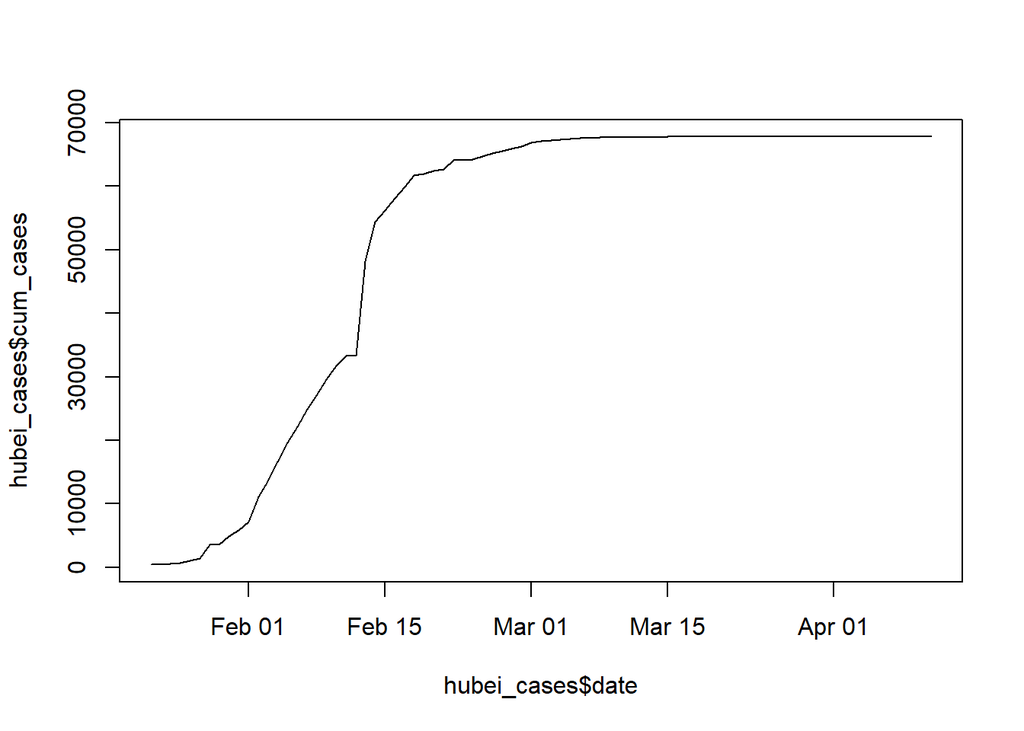

```r
hubei_cases <- cases %>% filter(province == 'Hubei')
plot(hubei_cases$date, hubei_cases$cum_cases, 'l')
```

```r
hubei_grm_fit <- optimizer(hubei_cases$cum_cases)
hubei_grm_fit
```

```
## $par
##            K            r            p            a
## 6.748366e+04 1.000000e+01 5.805342e-01 3.487302e+00
##
## $value
## [1] 209420364
##
## $counts
## function gradient
##       90       90
##
## $convergence
## [1] 0
##
## $message
## [1] "CONVERGENCE: REL_REDUCTION_OF_F <= FACTR*EPSMCH"
```

The model converged! Let’s make some predictions

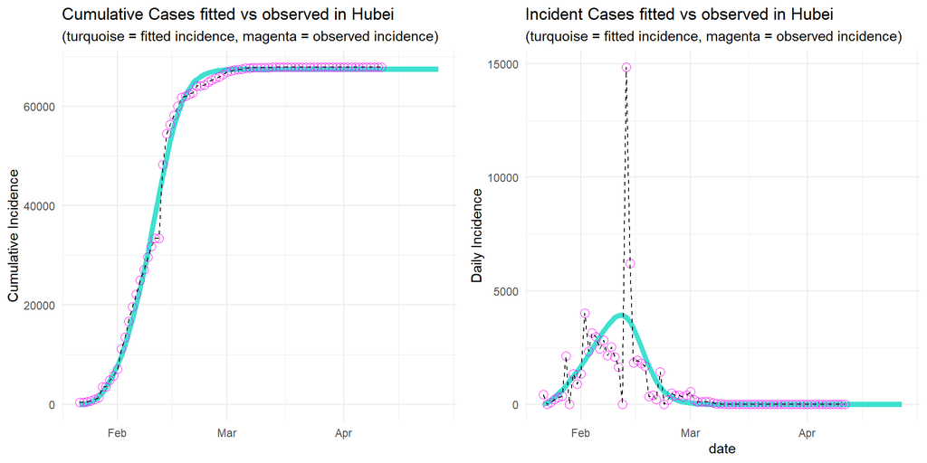

```r
hubei_preds <- make_preds(hubei_cases, hubei_grm_fit)
plot_grm_fits(hubei_preds, "Hubei")
```

#### Confirmed deaths

Let’s do the same for deaths

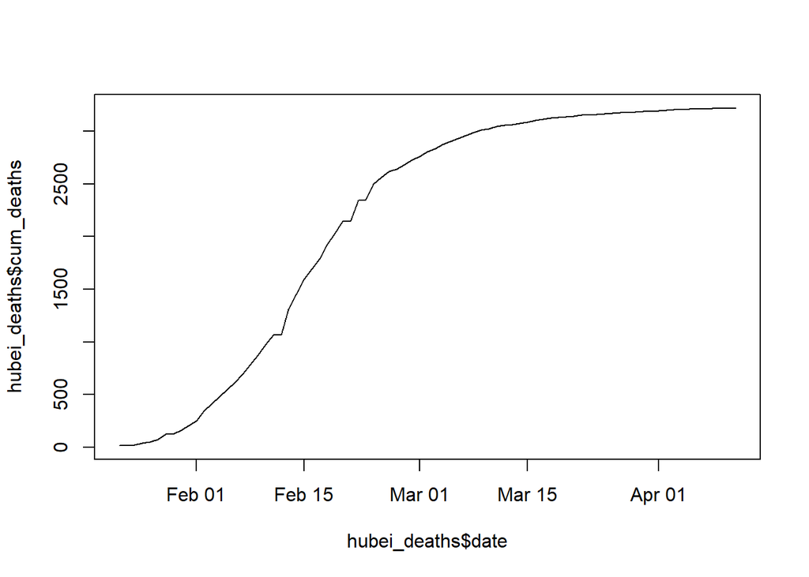

```r
hubei_deaths <- deaths %>% filter(province == 'Hubei')
plot(hubei_deaths$date, hubei_deaths$cum_deaths, 'l')
```

```r
hubei_deaths_grm_fit <- optimizer(hubei_deaths$cum_deaths, K_start = 5000)
hubei_deaths_grm_fit
```

```
## $par
##            K            r            p            a
## 3.274253e+03 9.998190e+00 9.271545e-01 1.526545e-02
##
## $value
## [1] 274344.4
##
## $counts
## function gradient
##      141      141
##
## $convergence
## [1] 0
##
## $message
## [1] "CONVERGENCE: REL_REDUCTION_OF_F <= FACTR*EPSMCH"
```

Predictions

```r
# Prediction function, default is 14 days forward of the last date of observed data
make_deaths_preds <- function(df, fit, t_fwd = 14) {
  t <- 1:(as.integer(today() - df$date[1]) + t_fwd)
  # Make predictions based on cumulative incidence
  preds <- data.frame(ode(y = c(C=1), times = t, func = GRM, parms = fit$par))
  preds <- preds %>%
    mutate(date = df$date[1] + days(t-1),
           C = round(C, 0),
           # uncumulate to get incidence
           I = c(C[1], diff(C))) %>%
    left_join(df %>% ungroup %>% select(date, cum_deaths, deaths))
  return(preds)
}
```

Lastly, create a plotting fucntion. We’ll plot both the cumulative and incidence fits against the observed data.

```r
plot_grm_deaths_fits <- function(df, name) {

  # Cumulative plot of observed vs fitted
  cum_plot <- ggplot(df, aes(x=date)) +
    geom_line(aes(y = C), color = "red", size = 2) +
    geom_point(aes(y = cum_deaths), color = "orange", shape = 1, size = 3) +
    geom_line(aes(y = cum_deaths), color = "gray10", linetype = "dashed") +
    labs(x = "", y = 'Cumulative Deaths',
         title = paste('Cumulative Deaths fitted vs observed in', name),
         subtitle = '(red = fitted incidence, orange = observed incidence)') +
    theme_minimal()

  # Incidence plot of observed vs fitted
  inc_plot <- ggplot(df, aes(x=date)) +
    geom_line(aes(y = I), color = "red", size = 2) +
    geom_point(aes(y = deaths), color = "orange", shape = 1, size = 3) +
    geom_line(aes(y = deaths), color = "gray10", linetype = "dashed") +
    labs(y = 'Daily Deaths', title = paste('Incident Deaths fitted vs observed in', name),
         subtitle = '(red = fitted incidence, orange = observed incidence)') +
    theme_minimal()

  gridExtra::grid.arrange(cum_plot, inc_plot, ncol = 2)
}
```

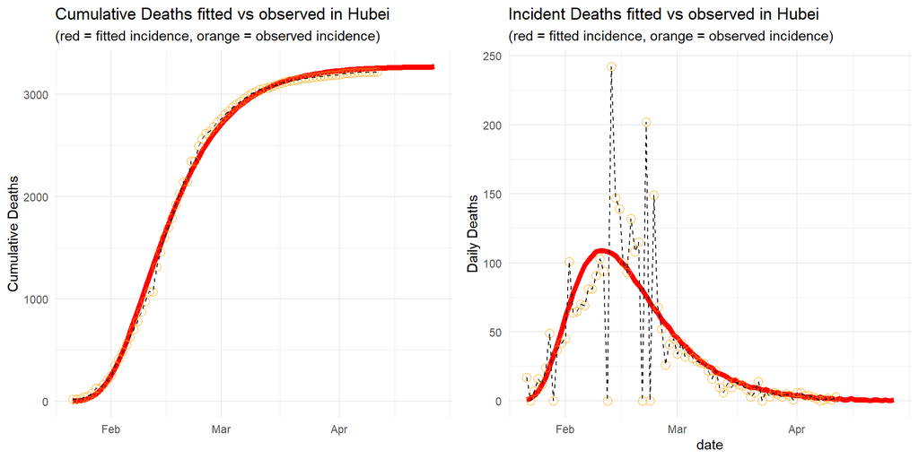

```r
hubei_deaths_preds <- make_deaths_preds(hubei_deaths, hubei_deaths_grm_fit)
plot_grm_deaths_fits(hubei_deaths_preds, "Hubei")
```

What’s the lag time in the peaks between confirmed cases and deaths

```r
hubei_preds %>% filter(I == max(I)) %>% pull(date);
```

```
## [1] "2020-02-12"
```

```r
hubei_deaths_preds %>% filter(I == max(I)) %>% pull(date)
```

```
## [1] "2020-02-10" "2020-02-11"
```

### Hong Kong

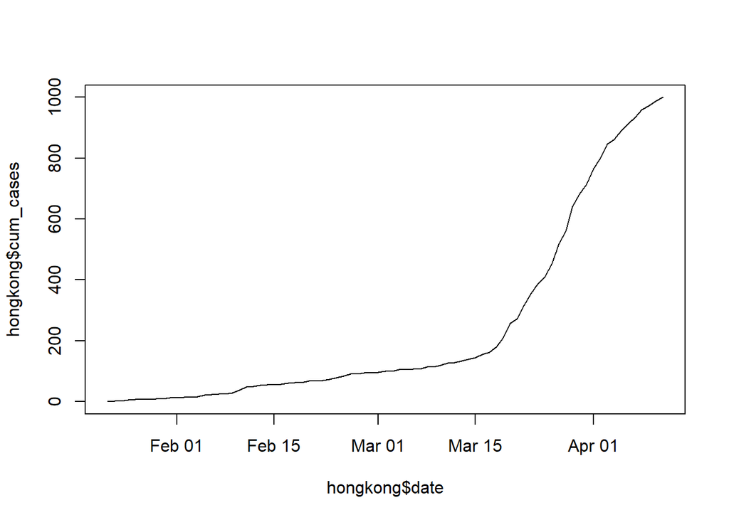

```r
hongkong <- cases %>% filter(province == 'Hong Kong')
plot(hongkong$date, hongkong$cum_cases, 'l')
```

For Hong Kong, we need to provide the starting r to help the model out. Let’s use the log-linear fit from the incidence package

```r
i.hk <- incidence((hongkong %>% select(date, cases) %>% uncount(cases))$date)
i.hk.peak <- find_peak(i.hk)
i.hk.fit <- incidence::fit(subset(i.hk, from = ymd('2020-02-28')), split = i.hk.peak)
```

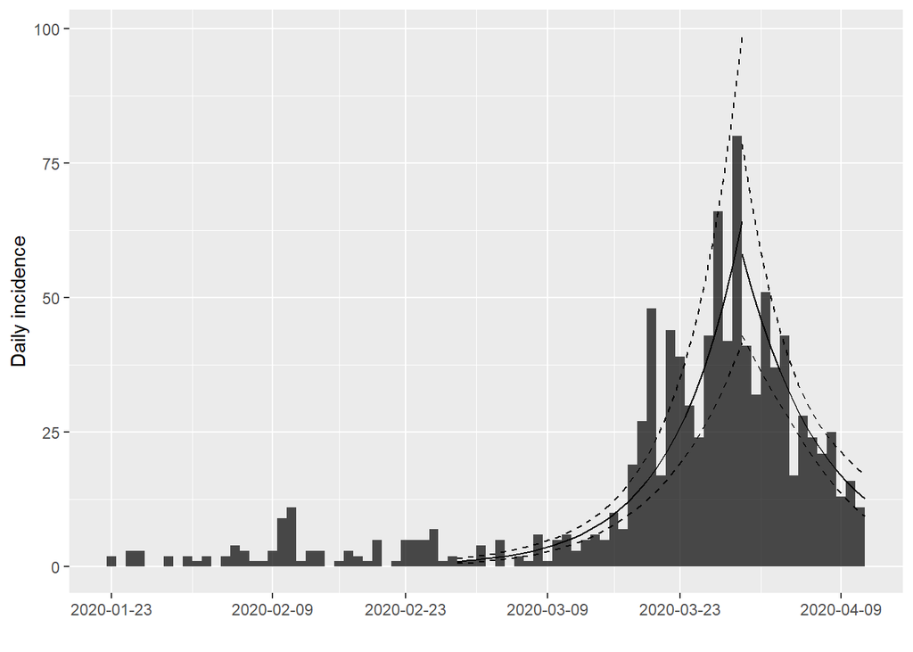

```r
plot(i.hk) %>% add_incidence_fit(i.hk.fit)
```

```r
i.hk.fit
```

```
## <list of incidence_fit objects>
##
## attr(x, 'locations'): list of vectors with the locations of each incidence_fit object
##
## 'before'
## 'after'
##
## $model: regression of log-incidence over time
##
## $info: list containing the following items:
##   $r (daily growth rate):
##     before      after
##  0.1390196 -0.1171971
##
##   $r.conf (confidence interval):
##             2.5 %     97.5 %
## before  0.1134611  0.1645782
## after  -0.1565596 -0.0778346
##
##   $doubling (doubling time in days):
##   before
## 4.985966
##
##   $doubling.conf (confidence interval):
##           2.5 %   97.5 %
## before 4.211658 6.109119
##
##   $halving (halving time in days):
##    after
## 5.914372
##
##   $halving.conf (confidence interval):
##         2.5 %   97.5 %
## after 4.42737 8.905386
##
##   $pred: data.frame of incidence predictions (43 rows, 6 columns)
```

```r
hongkong_grm_fit <- optimizer(hongkong$cum_cases, K_start = 200, r_start = 0.14)
hongkong_grm_fit
```

```
## $par
##           K           r           p           a
## 997.6494788   0.0964103   1.0000000   3.6750936
##
## $value
## [1] 79548.15
##
## $counts
## function gradient
##      173      173
##
## $convergence
## [1] 0
##
## $message
## [1] "CONVERGENCE: REL_REDUCTION_OF_F <= FACTR*EPSMCH"
```

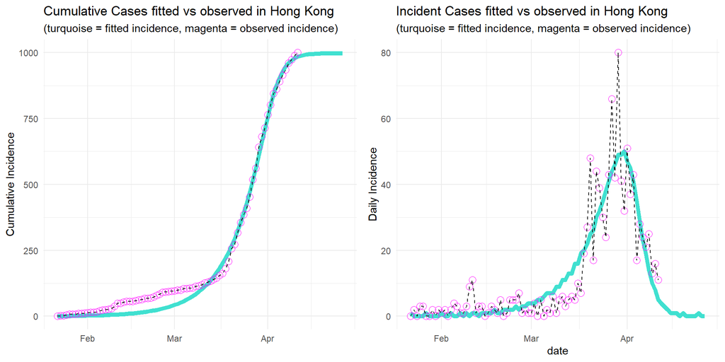

```r
hongkong_preds <- make_preds(hongkong, hongkong_grm_fit)
plot_grm_fits(hongkong_preds, "Hong Kong")
```

Great! That works.

### EVerything but Hubei, Hong Kong, Inner Mongolia, Beijing, Shanghai and Heilongjiang

Some of the provinces seem to be getting a second wave of cases. Let’s remove these and see if we can use the model

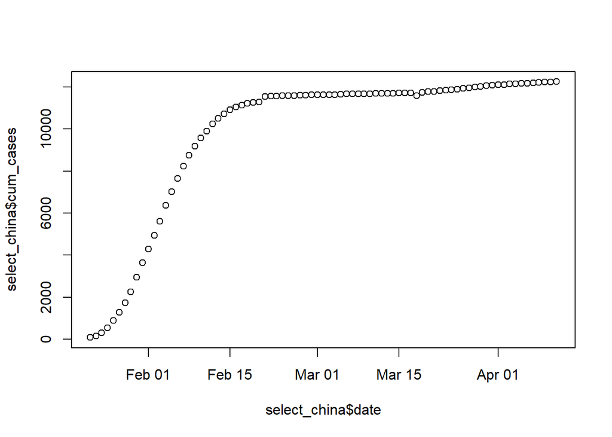

```r
to_rm <- c("Hubei", "Hong Kong", "Beijing", "Shanghai", "Inner Mongolia", "Heilongjiang")
select_china <- cases %>% filter(country == "China", !(province %in% to_rm)) %>%
  group_by(date) %>% summarise(cum_cases = sum(cum_cases), cases = sum(cases))

plot(select_china$date, select_china$cum_cases)
```

```r
i.select_china <- incidence((select_china %>% select(date, cases) %>% uncount(cases))$date)
i.select_china.peak <- find_peak(i.select_china)
i.select_china.fit <- incidence::fit(i.select_china, split = i.select_china.peak)
```

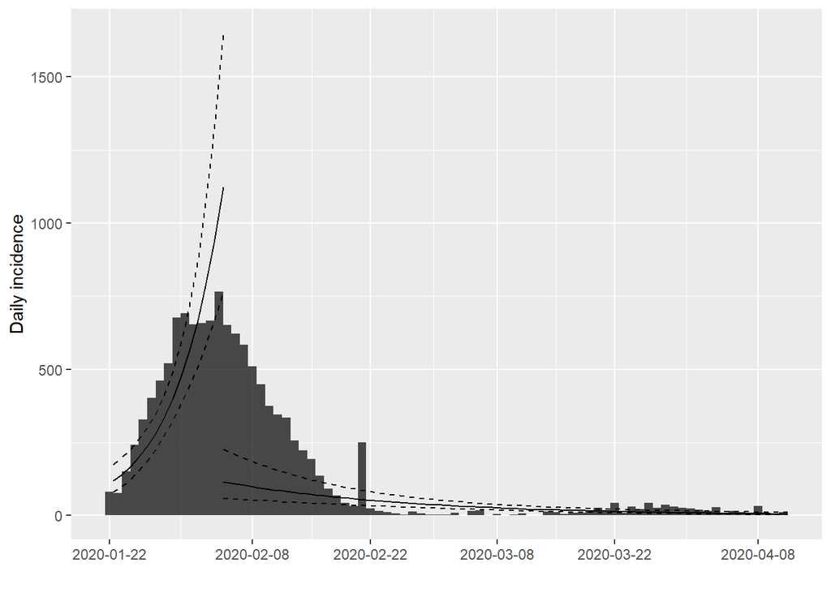

```r
plot(i.select_china) %>% add_incidence_fit(i.select_china.fit)
```

```r
i.select_china.fit
```

```
## <list of incidence_fit objects>
##
## attr(x, 'locations'): list of vectors with the locations of each incidence_fit object
##
## 'before'
## 'after'
##
## $model: regression of log-incidence over time
##
## $info: list containing the following items:
##   $r (daily growth rate):
##      before       after
##  0.17294921 -0.04507202
##
##   $r.conf (confidence interval):
##              2.5 %      97.5 %
## before  0.12254503  0.22335339
## after  -0.06240816 -0.02773588
##
##   $doubling (doubling time in days):
##   before
## 4.007808
##
##   $doubling.conf (confidence interval):
##           2.5 %   97.5 %
## before 3.103365 5.656265
##
##   $halving (halving time in days):
##    after
## 15.37866
##
##   $halving.conf (confidence interval):
##          2.5 %   97.5 %
## after 11.10668 24.99099
##
##   $pred: data.frame of incidence predictions (79 rows, 6 columns)
```

```r
select_china_grm_fit <- optimizer(select_china$cum_cases, K_start = 5000)
select_china_grm_fit
```

```
## $par
##            K            r            p            a
## 1.188104e+04 1.000000e+01 5.584026e-01 1.100157e+00
##
## $value
## [1] 2137877
##
## $counts
## function gradient
##       84       84
##
## $convergence
## [1] 0
##
## $message
## [1] "CONVERGENCE: REL_REDUCTION_OF_F <= FACTR*EPSMCH"
```

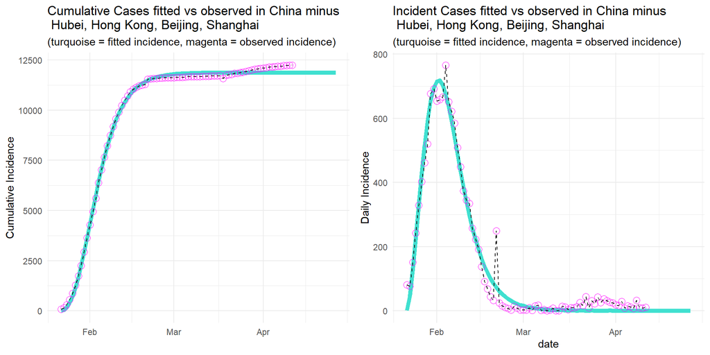

```r
select_china_preds <- make_preds(select_china, select_china_grm_fit)
plot_grm_fits(select_china_preds, paste("China minus\n", paste(to_rm[1:4], collapse = ", ")))
```

## South Korea

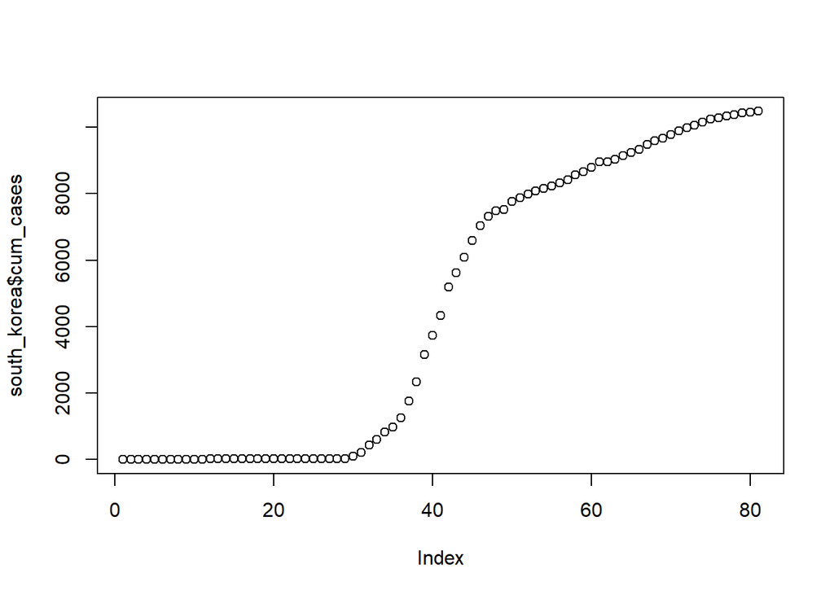

```r
south_korea <- cases %>% filter(country == "Korea, South")
plot(south_korea$cum_cases)
```

```r
south_korea_grm_fit <- optimizer(south_korea$cum_cases)
south_korea_grm_fit
```

```
## $par
##            K            r            p            a
## 9771.7699891    0.2299594    1.0000000    0.7778226
##
## $value
## [1] 14232482
##
## $counts
## function gradient
##      100      100
##
## $convergence
## [1] 0
##
## $message
## [1] "CONVERGENCE: REL_REDUCTION_OF_F <= FACTR*EPSMCH"
```

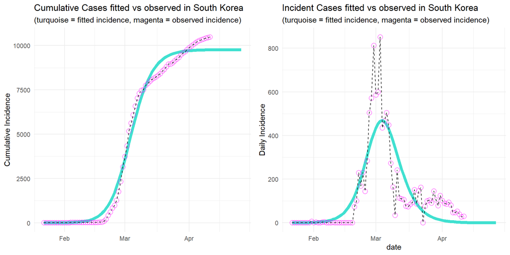

```r
south_korea_preds <- make_preds(south_korea, south_korea_grm_fit)
plot_grm_fits(south_korea_preds, "South Korea")
```

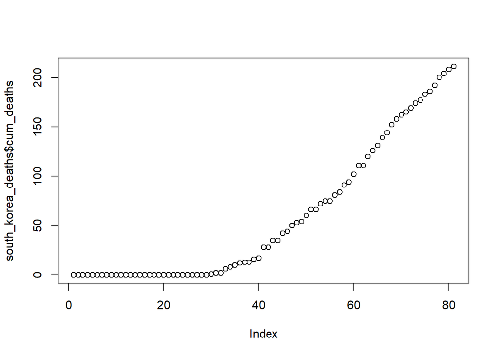

```r
south_korea_deaths <- deaths %>% filter(country == "Korea, South")
plot(south_korea_deaths$cum_deaths)
```

```r
south_korea_deaths_grm_fit <- optimizer(south_korea_deaths$cum_deaths, K_start = 10, r_start = 0.10)
south_korea_deaths_grm_fit
```

```
## $par
##            K            r            p            a
## 242.08766398   0.08409304   1.00000000   1.25928062
##
## $value
## [1] 1934.225
##
## $counts
## function gradient
##      133      133
##
## $convergence
## [1] 0
##
## $message
## [1] "CONVERGENCE: REL_REDUCTION_OF_F <= FACTR*EPSMCH"
```

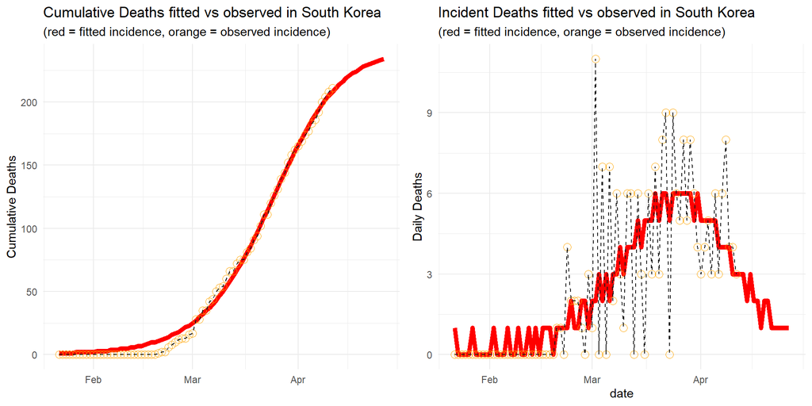

```r
south_korea_deaths_preds <- make_deaths_preds(south_korea_deaths, south_korea_deaths_grm_fit)
plot_grm_deaths_fits(south_korea_deaths_preds, "South Korea")
```

What’s the lag time in the peaks between confirmed cases and deaths

```r
ii <- south_korea_preds %>% filter(I == max(I)) %>% pull(date)
dd <- south_korea_deaths_preds %>% filter(I == max(I)) %>% pull(date)
ii[ceiling(length(ii)/2)]; dd[ceiling(length(dd)/2)]
```

```
## [1] "2020-03-04"
```

```
## [1] "2020-03-25"
```

## Italy

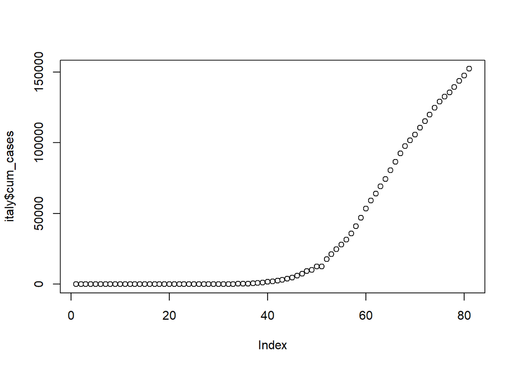

```r
italy <- cases %>% filter(country == "Italy")
plot(italy$cum_cases)
```

```r
italy_grm_fit <- optimizer(italy$cum_cases)
italy_grm_fit
```

```
## $par
##            K            r            p            a
## 1.686799e+05 7.155707e-01 7.868981e-01 1.999994e+01
##
## $value
## [1] 3950457336
##
## $counts
## function gradient
##      133      133
##
## $convergence
## [1] 0
##
## $message
## [1] "CONVERGENCE: REL_REDUCTION_OF_F <= FACTR*EPSMCH"
```

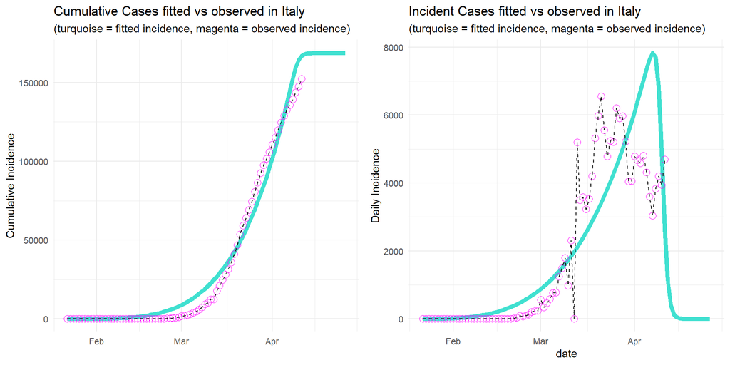

```r
italy_preds <- make_preds(italy, italy_grm_fit)
plot_grm_fits(italy_preds, "Italy")
```

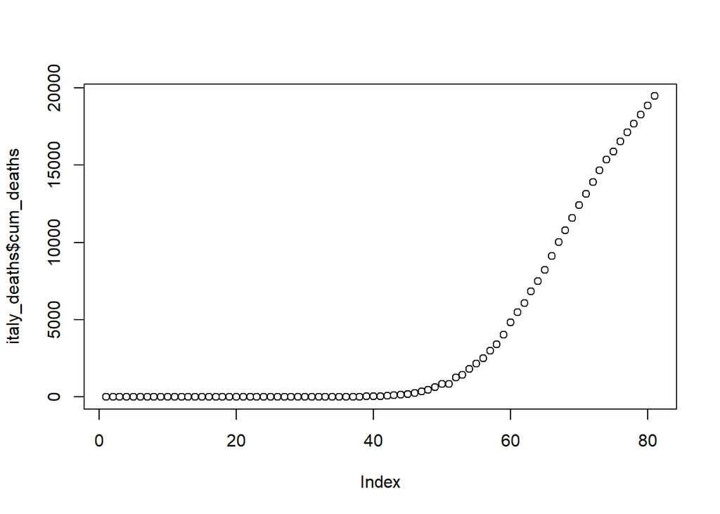

```r
italy_deaths <- deaths %>% filter(country == "Italy")
plot(italy_deaths$cum_deaths)
```

The GRM model struggles to fit the death data. We can use the Generalized Logistic Regression model using the `nlsLM` function from the `minpack.lm` package, which is:
$$C(t) = p/(1+exp(- \alpha\ (t- \beta\ ))$$

Reference: IHME (https://ihmeuw-msca.github.io/CurveFit/methods/)

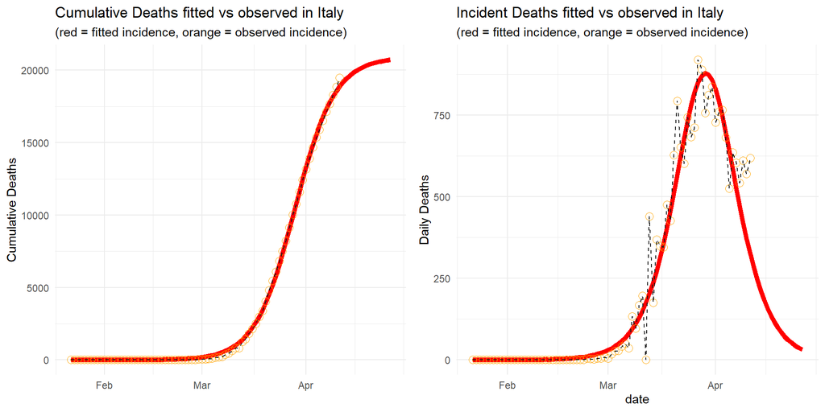

```r
italy_deaths <- italy_deaths %>% mutate(time = 1:nrow(italy_deaths))

# Fit using the generalized logistic model
italy_deaths_fit <-nlsLM(cum_deaths ~ p/(1 + exp(-a * (time-B))), italy_deaths,
                         start = list(a = 0.2, p = 0.5, B = 10), lower = c(0, 0, 0))

# Make predictions
t <- 1:(as.integer(today() - italy_deaths$date[1]) + 14)
italy_deaths_preds <- data.frame(t = t, C = predict(italy_deaths_fit, list(time=t)))
italy_deaths_preds <- italy_deaths_preds %>%
  mutate(date = italy_deaths$date[1] + days(t-1),
         C = round(C, 0),
         I = c(C[1], diff(C))) %>%
  left_join(italy_deaths %>% ungroup() %>% select(date, cum_deaths, deaths))

# Plot
plot_grm_deaths_fits(italy_deaths_preds, 'Italy')
```

## Spain

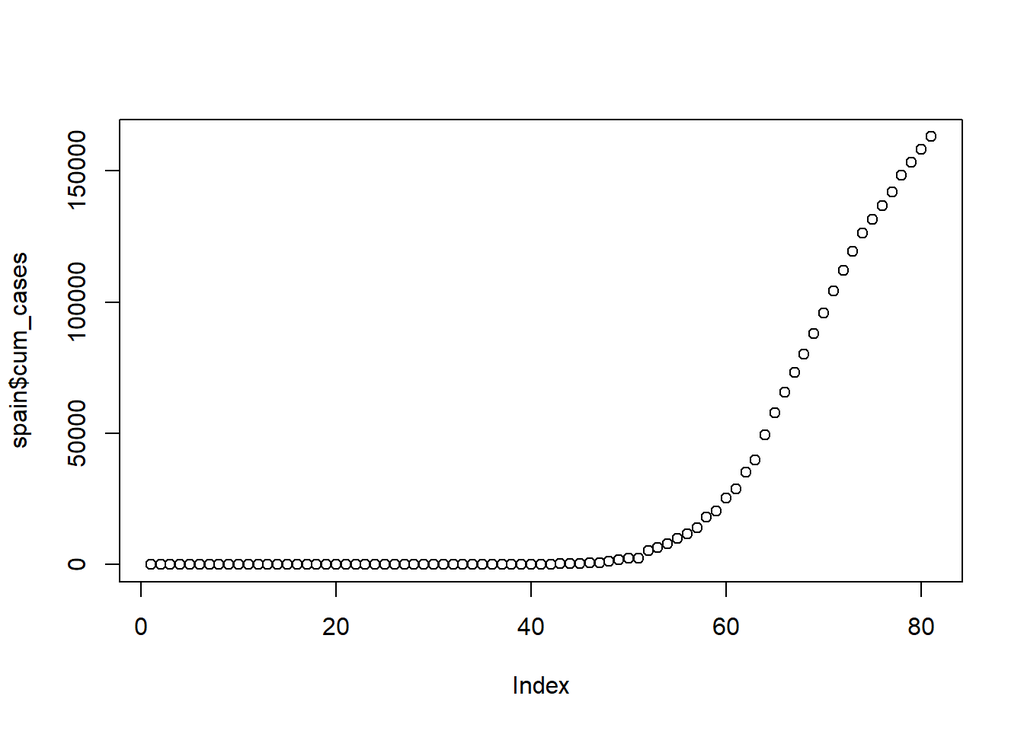

```r
spain <- cases %>% filter(country == "Spain")
plot(spain$cum_cases)
```

```r
spain_grm_fit <- optimizer(spain$cum_cases)
spain_grm_fit
```

```
## $par
##            K            r            p            a
## 1.537190e+05 2.770593e-01 9.157889e-01 1.490584e+01
##
## $value
## [1] 1697847339
##
## $counts
## function gradient
##      169      169
##
## $convergence
## [1] 0
##
## $message
## [1] "CONVERGENCE: REL_REDUCTION_OF_F <= FACTR*EPSMCH"
```

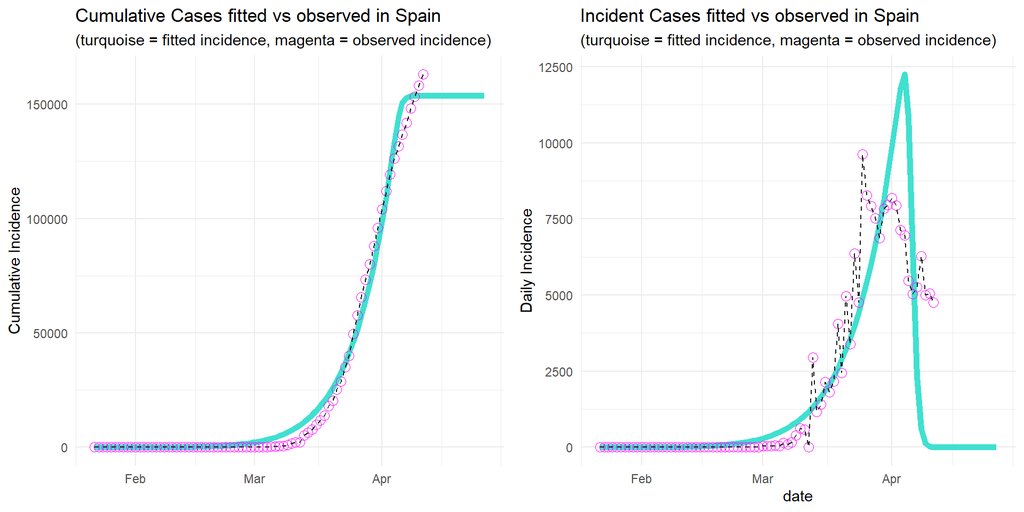

```r
spain_preds <- make_preds(spain, spain_grm_fit)
plot_grm_fits(spain_preds, "Spain")
```

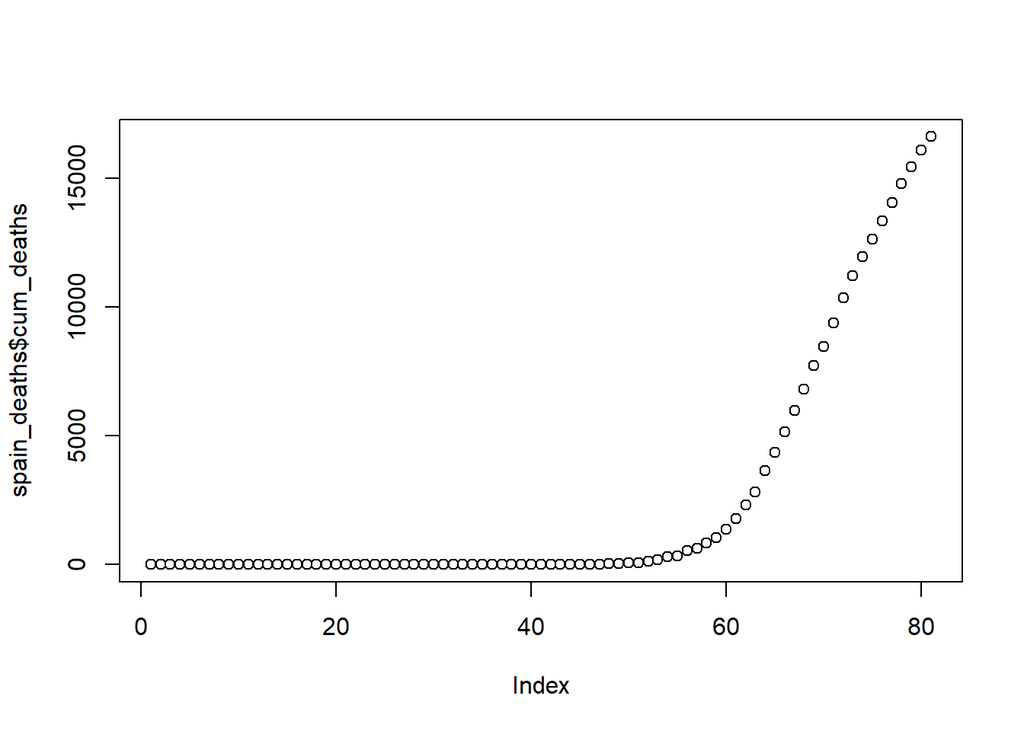

```r
spain_deaths <- deaths %>% filter(country == "Spain")
plot(spain_deaths$cum_deaths)
```

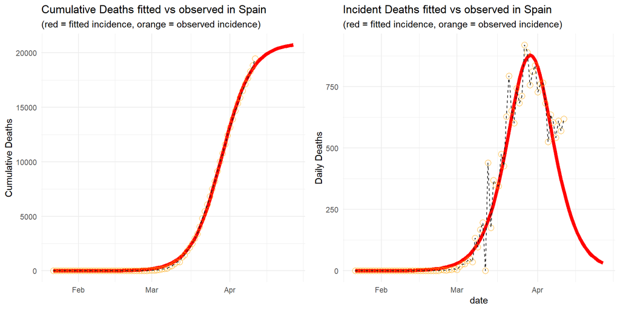

```r
spain_deaths <- spain_deaths %>% mutate(time = 1:nrow(spain_deaths))

# Fit using the generalized logistic model
spain_deaths_fit <-nlsLM(cum_deaths ~ p/(1 + exp(-a * (time-B))), spain_deaths,
                         start = list(a = 0.2, p = 0.5, B = 10), lower = c(0, 0, 0))

# Make predictions
t <- 1:(as.integer(today() - spain_deaths$date[1]) + 14)
spain_deaths_preds <- data.frame(t = t, C = predict(spain_deaths_fit, list(time=t)))
spain_deaths_preds <- italy_deaths_preds %>%
  mutate(date = italy_deaths$date[1] + days(t-1),
         C = round(C, 0),
         I = c(C[1], diff(C))) %>%
  left_join(spain_deaths %>% ungroup() %>% select(date, cum_deaths, deaths))

# Plot
plot_grm_deaths_fits(spain_deaths_preds, 'Spain')
```

## Germany

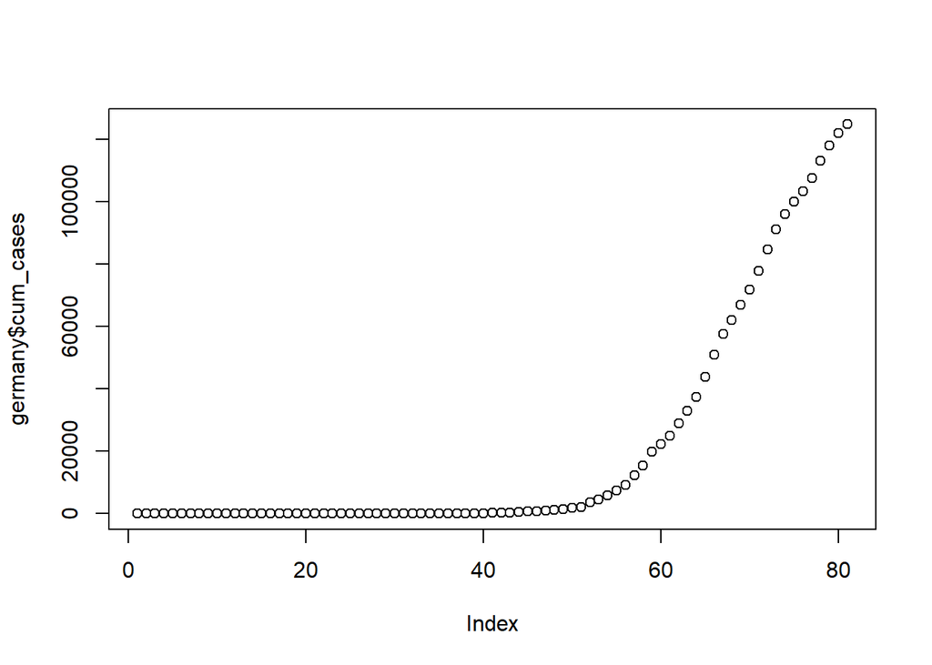

```r
germany <- cases %>% filter(country == "Germany")
plot(germany$cum_cases)
```

```r
germany_grm_fit <- optimizer(germany$cum_cases)
germany_grm_fit
```

```
## $par
##            K            r            p            a
## 1.194792e+05 2.888860e-01 9.033531e-01 2.000000e+01
##
## $value
## [1] 1093830927
##
## $counts
## function gradient
##      128      128
##
## $convergence
## [1] 0
##
## $message
## [1] "CONVERGENCE: REL_REDUCTION_OF_F <= FACTR*EPSMCH"
```

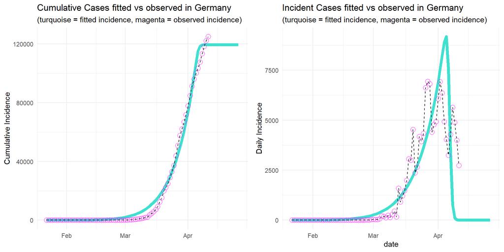

```r
germany_preds <- make_preds(germany, germany_grm_fit)


# Fit using the generalized logistic model
germany_glm_fit <-nlsLM(cum_cases ~ p/(1 + exp(-a * (time-B))), germany_preds,
                         start = list(a = 0.2, p = 0.5, B = 10), lower = c(0, 0, 0))

# Make predictions
germany_preds$glm <- predict(germany_glm_fit, list(time=germany_preds$time))

# Plot
plot_grm_fits(germany_preds, 'Germany')
```

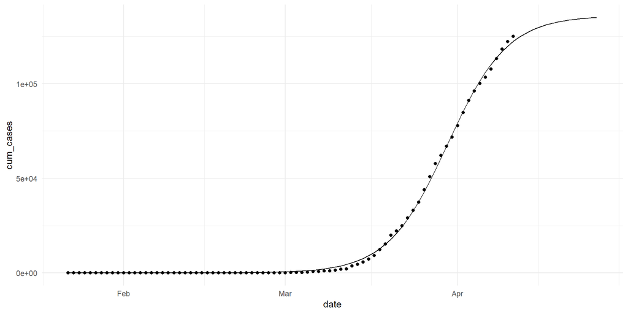

```r
ggplot(germany_preds, aes(x = date)) + geom_point(aes(y = cum_cases)) + geom_line(aes(y = glm)) + theme_minimal()
```

In the test run above, the NLS LM using the **Levenberg-Marquardt** is better and faster.

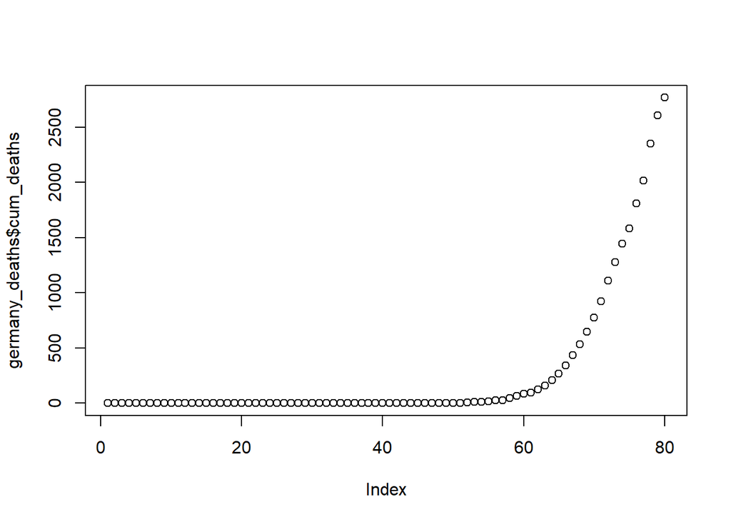

```r
germany_deaths <- deaths %>% filter(country == "Germany")
plot(germany_deaths$cum_deaths)
```

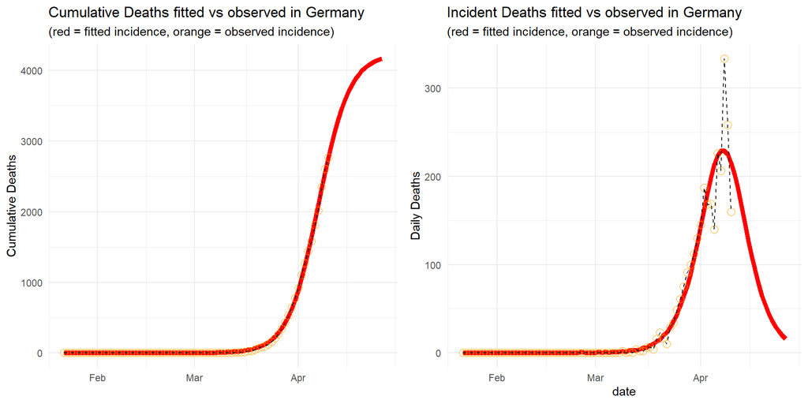

```r
germany_deaths <- germany_deaths %>% mutate(time = 1:nrow(germany_deaths))

# Fit using the generalized logistic model
germany_deaths_fit <-nlsLM(cum_deaths ~ p/(1 + exp(-a * (time-B))), germany_deaths,
                         start = list(a = 0.2, p = 0.5, B = 10), lower = c(0, 0, 0))

# Make predictions
t <- 1:(as.integer(today() - germany_deaths$date[1]) + 14)
germany_deaths_preds <- data.frame(t = t, C = predict(germany_deaths_fit, list(time=t)))
germany_deaths_preds <- germany_deaths_preds %>%
  mutate(date = germany_deaths$date[1] + days(t-1),
         C = round(C, 0),
         I = c(C[1], diff(C))) %>%
  left_join(germany_deaths %>% ungroup() %>% select(date, cum_deaths, deaths))

# Plot
plot_grm_deaths_fits(germany_deaths_preds, 'Germany')
```

Final thoughts: `nlslm` is way faster than using the optim function for GRM and may even be more accurate. Moving forward that’s what I’ll use.